# MIMIC-III Lab Events Item ID

March 2019

```r
# Data preparation
library('psych')          # descriptive stats

# Plots and tables
library('knitr')          # knitting Rmd to HTML; kable() function
library('kableExtra')     # extra formating options for knitr tables
library('ggplot2')        # 2d plotting
library('ggpubr')         # extra formatting options for ggplot
```

**Random Seed Set**

```r
set.seed(123456)
```

# 1 Extracting the data

We first calculated the total number of distinct itemids:

`SELECT count(distinct itemid) FROM labevents as items_count`

And the result gives us `726`, showing us that there are 726 itemids from labevents.

Then we calculated the 25 most common itemids:

Which gives us the table:

```r
frequency_data <- read.csv('count.csv')
str(frequency_data)
```

```
## 'data.frame':    25 obs. of  2 variables:
##  $ itemid: int  51221 50971 50983 50912 50902 51006 50882 51265 50868 51301 ...
##  $ count : int  881764 845737 808401 797389 795480 791838 780648 778365 769810 753221 ...
```

```r
kable(frequency_data, caption="The 25 most common itemids") %>%
kable_styling(bootstrap_options='striped')
```

The 25 most common itemids

| itemid | count |
| --- | --- |
| 51221 | 881764 |
| 50971 | 845737 |
| 50983 | 808401 |
| 50912 | 797389 |
| 50902 | 795480 |
| 51006 | 791838 |
| 50882 | 780648 |
| 51265 | 778365 |
| 50868 | 769810 |
| 51301 | 753221 |
| 51222 | 752444 |
| 50931 | 748896 |
| 51249 | 748147 |
| 51279 | 747999 |
| 51248 | 747994 |
| 51250 | 747977 |
| 51277 | 746817 |
| 50960 | 664123 |
| 50893 | 591932 |
| 50970 | 590502 |
| 50820 | 530752 |
| 50802 | 490651 |
| 50804 | 490641 |
| 50821 | 490628 |
| 50818 | 490594 |

Then by finding those 25 itemids in the corresponding d_labitems, we see what they map to:

```r
itemid_data <- read.csv('25 itemids.csv')
str(itemid_data)
```

```
## 'data.frame':    25 obs. of  6 variables:
##  $ row_id    : int  3 5 19 21 22 69 83 94 103 113 ...
##  $ itemid    : int  50802 50804 50818 50820 50821 50868 50882 50893 50902 50912 ...
##  $ label     : Factor w/ 25 levels "Anion Gap","Base Excess",..: 2 5 15 16 19 1 3 4 6 7 ...
##  $ fluid     : Factor w/ 1 level "Blood": 1 1 1 1 1 1 1 1 1 1 ...
##  $ category  : Factor w/ 3 levels "Blood Gas","Chemistry",..: 1 1 1 1 1 2 2 2 2 2 ...
##  $ loinc_code: Factor w/ 25 levels "11555-0","11556-8",..: 1 16 3 4 2 5 6 7 8 9 ...
```

```r
kable(itemid_data, caption="The 25 most common itemids") %>%
kable_styling(bootstrap_options='striped')
```

The 25 most common itemids

| row_id | itemid | label | fluid | category | loinc_code |
| --- | --- | --- | --- | --- | --- |
| 3 | 50802 | Base Excess | Blood | Blood Gas | 11555-0 |
| 5 | 50804 | Calculated Total CO2 | Blood | Blood Gas | 34728-6 |
| 19 | 50818 | pCO2 | Blood | Blood Gas | 11557-6 |
| 21 | 50820 | pH | Blood | Blood Gas | 11558-4 |
| 22 | 50821 | pO2 | Blood | Blood Gas | 11556-8 |
| 69 | 50868 | Anion Gap | Blood | Chemistry | 1863-0 |
| 83 | 50882 | Bicarbonate | Blood | Chemistry | 1963-8 |
| 94 | 50893 | Calcium, Total | Blood | Chemistry | 2000-8 |
| 103 | 50902 | Chloride | Blood | Chemistry | 2075-0 |
| 113 | 50912 | Creatinine | Blood | Chemistry | 2160-0 |
| 132 | 50931 | Glucose | Blood | Chemistry | 2345-7 |
| 161 | 50960 | Magnesium | Blood | Chemistry | 2601-3 |
| 171 | 50970 | Phosphate | Blood | Chemistry | 2777-1 |
| 172 | 50971 | Potassium | Blood | Chemistry | 2823-3 |
| 184 | 50983 | Sodium | Blood | Chemistry | 2951-2 |
| 206 | 51006 | Urea Nitrogen | Blood | Chemistry | 3094-0 |
| 421 | 51221 | Hematocrit | Blood | Hematology | 4544-3 |
| 422 | 51222 | Hemoglobin | Blood | Hematology | 718-7 |
| 448 | 51248 | MCH | Blood | Hematology | 785-6 |
| 449 | 51249 | MCHC | Blood | Hematology | 786-4 |
| 450 | 51250 | MCV | Blood | Hematology | 787-2 |
| 465 | 51265 | Platelet Count | Blood | Hematology | 777-3 |
| 477 | 51277 | RDW | Blood | Hematology | 788-0 |
| 479 | 51279 | Red Blood Cells | Blood | Hematology | 789-8 |
| 501 | 51301 | White Blood Cells | Blood | Hematology | 804-5 |

Since each itemid stands for a distinct lab test, we determined that none of the itemids are likely to be redundant, and so there was no need to merge any of them.

(MCV is a measurement of the average size of your red blood cells. MCH results tend to mirror MCV results. This is because bigger red blood cells generally contain more hemoglobin while smaller red blood cells tend to have less.

MCHC is a calculation of the amount of hemoglobin per unit volume in a single red blood cell. The difference between MCH and MCHC is that the MCHC measurement takes the volume or size of the red blood cell into account while MCH does not.)

Site: https://www.healthline.com/health/mch

# 2 Plots for itemids

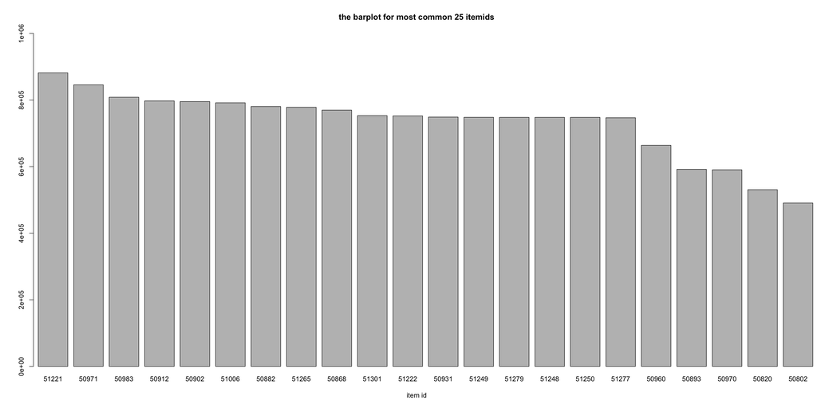

```r
barplot(frequency_data$count,names.arg=frequency_data$itemid,xlim=c(1,25),ylim=c(0,10^6),xlab='item id',main='the barplot for most common 25 itemids')
```

And a pie chart that shows the frequency of all itemids:

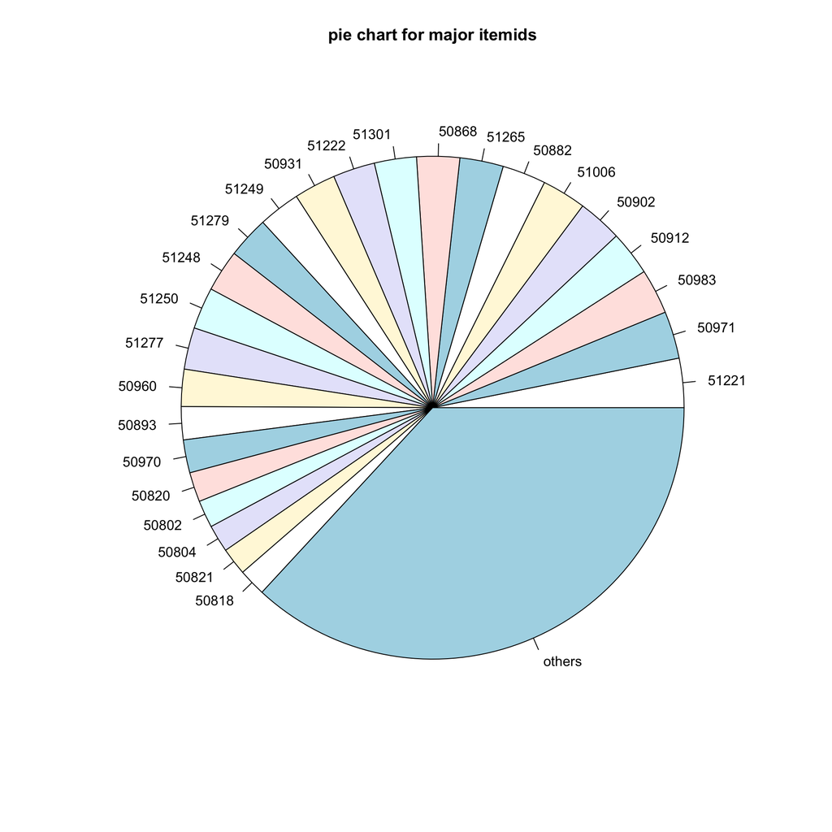

```r
frequency_all_data <- read.csv('count_all.csv')
de<-data.frame(itemid='others',count=sum(frequency_all_data$count[26:726]))
new_frequency<-rbind(frequency_all_data[1:25,],de)
pie(new_frequency$count,labels =new_frequency$itemid,main='pie chart for major itemids')
```

# 3 Bar Charts for itemids

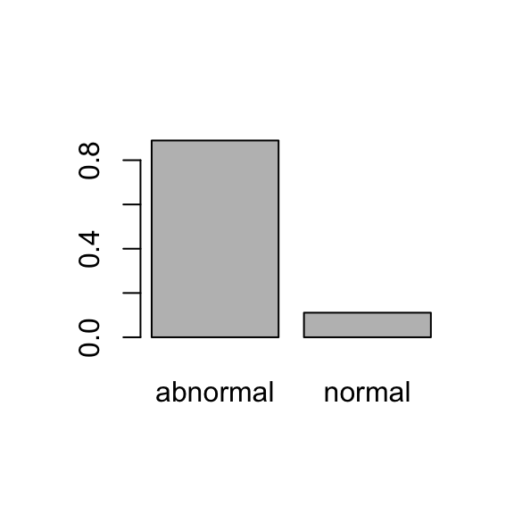

```r
data_51221 <- read.csv('51221.csv')

for (i in 1:nrow(data_51221)) {
  if (data_51221$flag[i] == "") {
    data_51221$flag_1[i] <- "normal"
  }
  else {
    data_51221$flag_1[i] <- "abnormal"
  }
}

barplot(prop.table(table(data_51221$flag_1)))
```

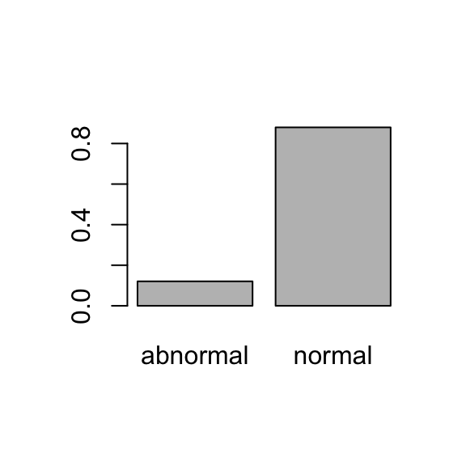

```r
data_50971 <- read.csv('50971.csv')

for (i in 1:nrow(data_50971)) {
  if (data_50971$flag[i] == "") {
    data_50971$flag_1[i] <- "normal"
  }
  else {
    data_50971$flag_1[i] <- "abnormal"
  }
}

barplot(prop.table(table(data_50971$flag_1)))
```

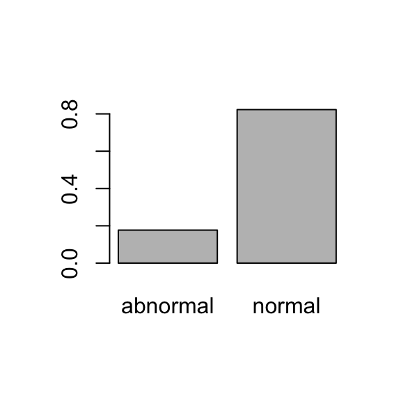

```r
data_50983 <- read.csv('50983.csv')

for (i in 1:nrow(data_50983)) {
  if (data_50983$flag[i] == "") {
    data_50983$flag_1[i] <- "normal"
  }
  else {
    data_50983$flag_1[i] <- "abnormal"
  }
}

barplot(prop.table(table(data_50983$flag_1)))
```

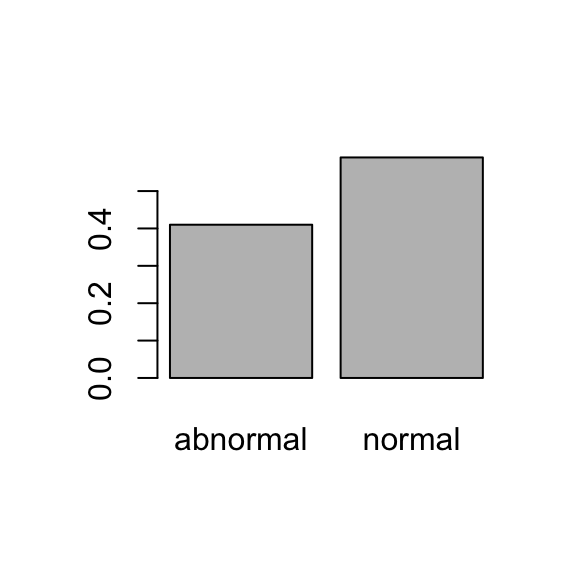

```r
data_50912 <- read.csv('50912.csv')

for (i in 1:nrow(data_50912)) {
  if (data_50912$flag[i] == "") {
    data_50912$flag_1[i] <- "normal"
  }
  else {
    data_50912$flag_1[i] <- "abnormal"
  }
}

barplot(prop.table(table(data_50912$flag_1)))
```

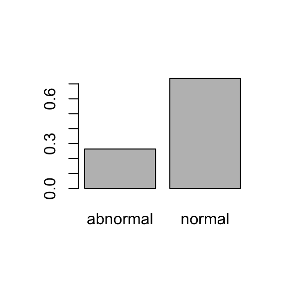

```r
data_50902 <- read.csv('50902.csv')

for (i in 1:nrow(data_50902)) {
  if (data_50902$flag[i] == "") {
    data_50902$flag_1[i] <- "normal"
  }
  else {
    data_50902$flag_1[i] <- "abnormal"
  }
}

barplot(prop.table(table(data_50902$flag_1)))
```

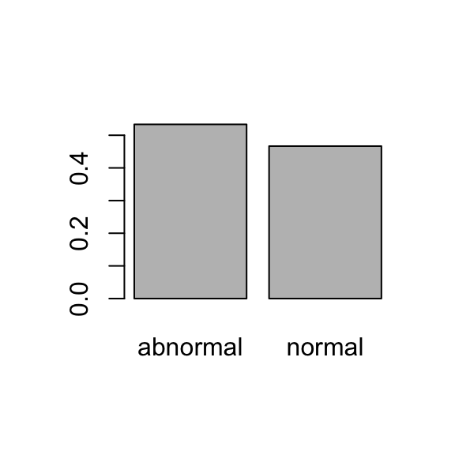

```r
data_51006 <- read.csv('51006.csv')

for (i in 1:nrow(data_51006)) {
  if (data_51006$flag[i] == "") {
    data_51006$flag_1[i] <- "normal"
  }
  else {
    data_51006$flag_1[i] <- "abnormal"
  }
}

barplot(prop.table(table(data_51006$flag_1)))
```

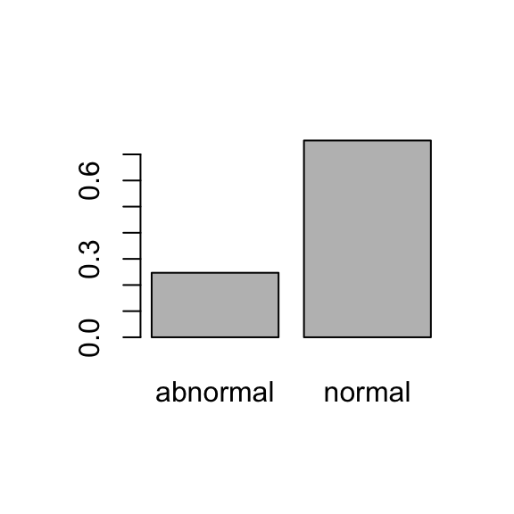

```r
data_50882 <- read.csv('50882.csv')

for (i in 1:nrow(data_50882)) {
  if (data_50882$flag[i] == "") {
    data_50882$flag_1[i] <- "normal"
  }
  else {
    data_50882$flag_1[i] <- "abnormal"
  }
}

barplot(prop.table(table(data_50882$flag_1)))
```